# Error, Uncertainty and the Linear Model

Lecture 2

Dr. Emre Yucel

2026-09-02

# Measuring prediction error

## Predicting price from area

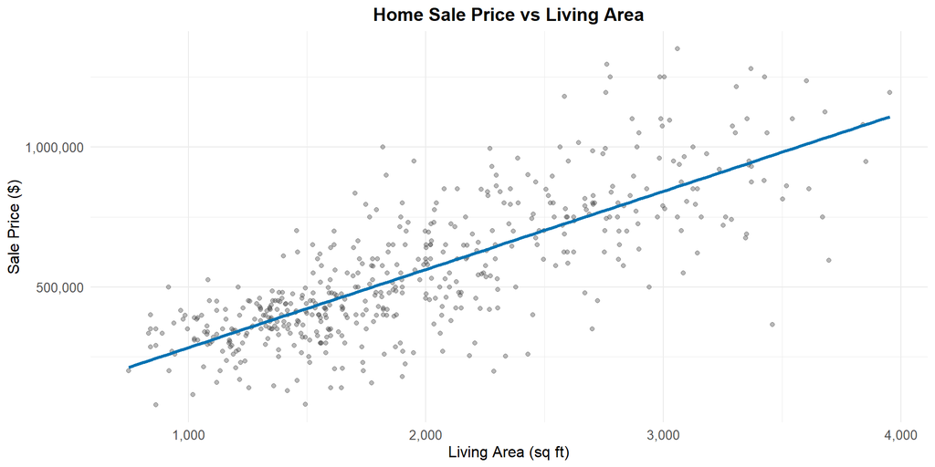

## Residuals and fitted values

- The **fitted value** (“y hat”) for observation $i$ is the predicted value from the regression line:
  $$\widehat{y}_i = \widehat{\beta_0} + \widehat{\beta_1} \times \text{area}_i$$
- The **residual** is the corresponding prediction error:
  $$e_i = y_i - \widehat{y}_i = \text{observed price} - \text{predicted price}$$
- When a linear model fits well,
  - The fitted line tells us about the part of price **predictable** from area
  - The residuals tell us about the part of price **not predictable** from area

## Visualizing residuals and fitted values

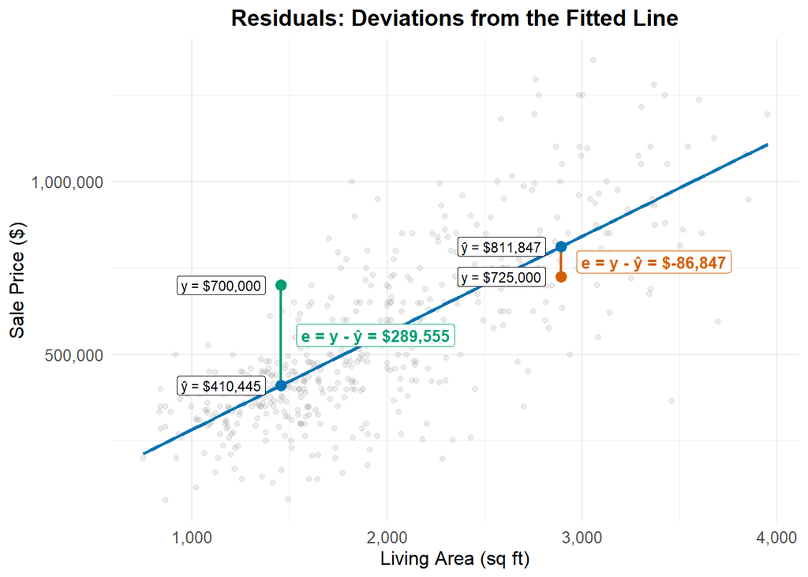

## What does a residual tell us?

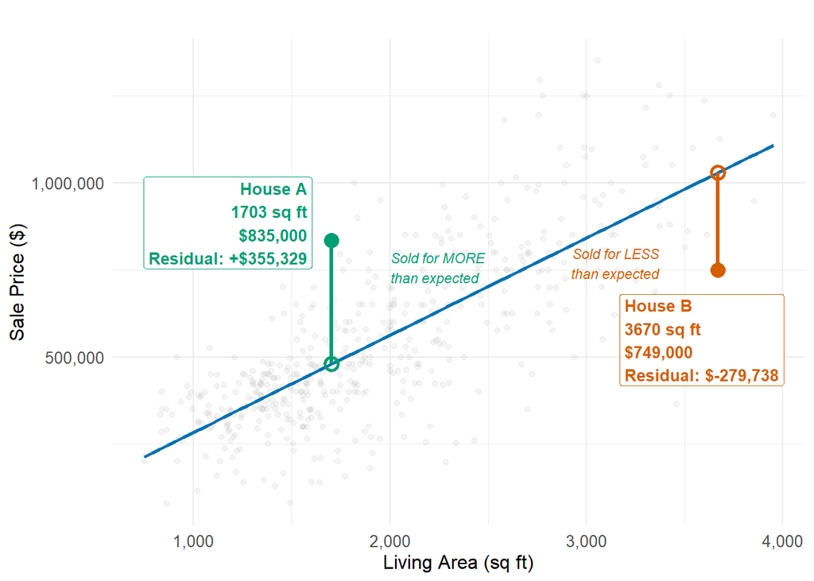

## What is a “typical” residual?

- The residual tells us the prediction error for a given point
- The **standard deviation of the residuals** tells us the typical **size** of these prediction errors (in absolute value)
- It’s a measure of how **variable our prediction errors are**
  - Low variability: our predictions are usually close to actual values
  - High variability: our predictions are often far off from actual values
- In $R$, this is called the **Residual Standard Error (RSE)**

```r
summary(fit)
```

```
Call:
lm(formula = price ~ area, data = houses)

Residuals:
    Min      1Q  Median      3Q     Max
-604840  -90641    2955   83298  519720

Coefficients:
             Estimate Std. Error t value            Pr(>|t|)
(Intercept)  4296.668  21017.955  0.2044              0.8381
area          279.139     10.101 27.6337 <0.0000000000000002 ***
---
Signif. codes:  0 '***' 0.001 '**' 0.01 '*' 0.05 '.' 0.1 ' ' 1

Residual standard error: 155630 on 506 degrees of freedom
Multiple R-squared:  0.60146,   Adjusted R-squared:  0.60067
F-statistic: 763.62 on 1 and 506 DF,  p-value: < 0.000000000000000222
```

From line 16: RSE = $155,630

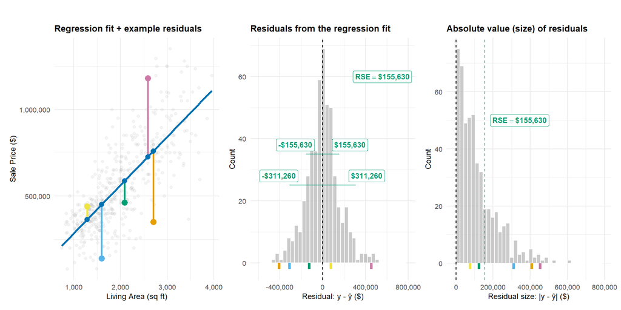

## $R^2$ (R-squared)

$R^2$ is a measure of the **strength of the linear relationship** between the $Y$ and all $X$’s in the linear regression

- $R^2$ ranges from 0 to 1
  - 0 = no linear relationship
  - 1 = perfect linear relationship
- Related to *correlation*

$Cor(X,Y)$ measures linear association between two variables

- Between -1 and 1
- Sign indicates direction of linear relationship
- Magnitude indicates strength of linear relationship (0=none, $\pm 1$=perfect)

## Correlation

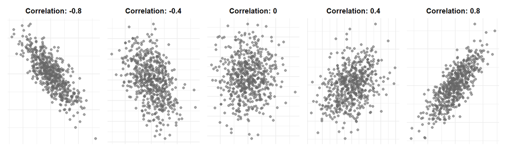

## Defining $R^2$ (R-squared)

$R^2$ has two equivalent definitions:

1. The squared correlation between observed and fitted values from the regression model
2. The proportion of variance in the outcome $Y$ “explained” by the regression model

## Finding $R^2$

```r
summary(fit)
```

```
Call:
lm(formula = price ~ area, data = houses)

Residuals:
    Min      1Q  Median      3Q     Max
-604840  -90641    2955   83298  519720

Coefficients:
             Estimate Std. Error t value            Pr(>|t|)
(Intercept)  4296.668  21017.955  0.2044              0.8381
area          279.139     10.101 27.6337 <0.0000000000000002 ***
---
Signif. codes:  0 '***' 0.001 '**' 0.01 '*' 0.05 '.' 0.1 ' ' 1

Residual standard error: 155630 on 506 degrees of freedom
Multiple R-squared:  0.60146,   Adjusted R-squared:  0.60067
F-statistic: 763.62 on 1 and 506 DF,  p-value: < 0.000000000000000222
```

Line 17 (Multiple R-squared): $R^2 = 0.601$ (we’ll cover adjusted $R^2$ later)

## $R^2 = Cor(Y, Ŷ)^2$

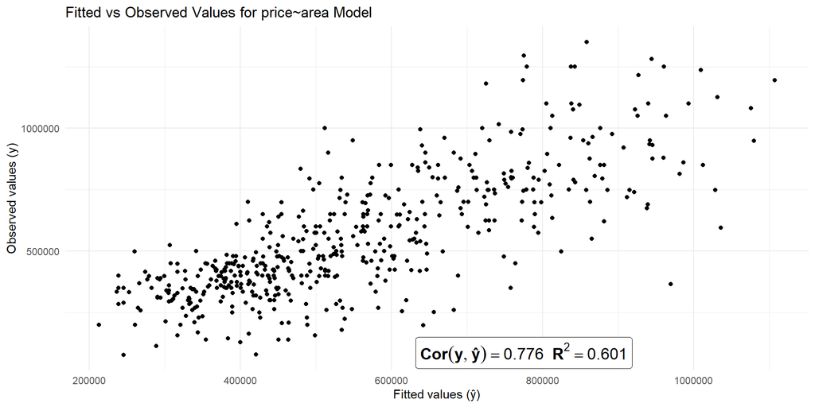

## $R^2$ as generalized correlation

- $R^2$ tells us **how closely the predicted values track actual values**
- In a simple linear model, it’s the same as $Cor(X,Y)^2$
- So you can think of $R^2$ as a generalization of correlation to multiple X’s

## $R^2$ as generalized correlation

It inherits the same limitations as correlation:

- Low $R^2$ does **not** imply
  - No “meaningful” linear relationship
  - No strong *nonlinear* relationship

## $R^2$ as generalized correlation

- High $R^2$ does **not** imply
  - A *causal* relationship
  - A true *linear* relationship
  - Prediction errors are small enough to be useful
  - The model will predict well for *future* data

## $R^2$ as proportion of variance “explained”

- If $R^2$ is high then our predictions track the observed values closely
- $R^2$ measures how much unpredictability (variance) in the outcome “goes away” when we ues X to predict

## $R^2$ as proportion of variance “explained”

$$R^2 = \frac{\overbrace{\text{variance of Y} - \text{variance of residuals}}^{\text{variance ``explained''}}}{\text{variance of Y}}$$

- Common phrasing: “$R^2$ is the proportion of variance in $Y$ explained by the model”

## $R^2$ as proportion of variance “explained”

- The variance of $Y$ is also the variance of the residuals under a simple regression model where we force $\hat\beta_1=0$
- So we can think about $R^2$ as the reduction in variance (average size) of our residuals when using $X$ to predict $Y$ compared to not using X at all
- If we force $\hat\beta_1=0$, all of our predictions will be $\bar y$ (the average $Y$ value)

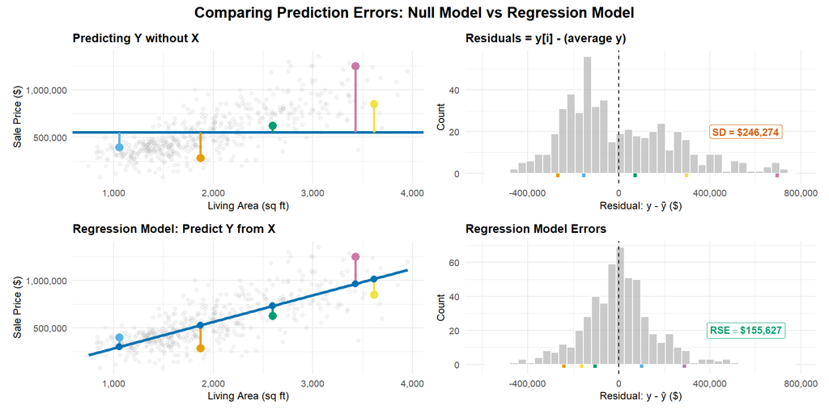

## $R^2$ as proportion of variance “explained”

$$R^2 = \frac{246,274^2 - 155,630^2}{246,274^2}\approx 0.601$$

- We say $X$ “explained” 60.1% ($R^2=0.601$) of the total variability in $Y$
- Remember: this is just a way of quantifying how closely the line tracks actual values
  - You can predict something without being able to explain why it happens!

## Multiple or Adjusted $R^2$?

- The only difference is how residual variance is estimated
- In practice, the difference is usually small
  - If they’re very different then neither is very reliable
- On a HW/Quiz you can use either
- Later we’ll see how to get more accurate measures of prediction error

## $R^2$ or RSE?

- $R^2$ measures the **strength of the linear relationship** between $Y$ and the $X$’s
  - Since it’s a relative measure, we don’t know how big our prediction errors are likely to be
- $RSE$ measures the **typical size of our prediction errors** using $X$ to predict $Y$
  - Since it’s an absolute measure, we don’t know how strong the linear relationship is

Both can be useful, but in practice RSE is usually more relevant.

## $R^2$ or RSE?

Predicting the price of a house from its area:

- $R^2$ = 0.601
- RSE = $155,630

Pretty strong linear relationship, but typical prediction errors are still very large!

## Why?

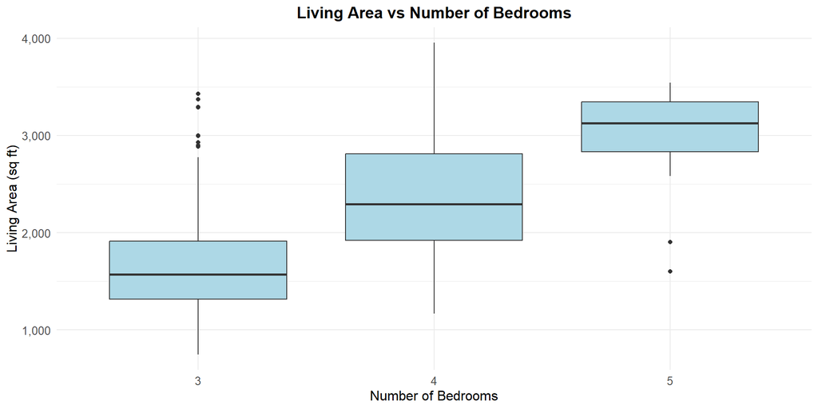

## Prediction isn’t everything

# Incorporating uncertainty

## Accounting for error and uncertainty

- So far we’ve focused on estimated coefficients and predictions
- We know our predictions will be wrong – how wrong are the likely to be?
- We know our coefficients don’t match the true population values – how close are they?

## The simple linear regression model

We need a *model* for our data to answer these questions. Our model has four components:

- **L**inearity
- **I**ndependence of prediction errors
- **N**ormality of prediction errors
- **E**qual variance of prediction errors

## Linearity

The relationship between $Y$ and each $X$ is linear:

$Y = \beta_0 + \beta_1 X_{1} + \beta_2 X_{2} + ... + \beta_p X_{p} + \epsilon$

- $\beta_0, \beta_1, ..., \beta_p$ are the **true/population** regression coefficients
- $\epsilon$ is the **true** error if we predict $Y$ using the **true** regression coefficients

Our other assumptions are about those true error terms $\epsilon$…

## Independence

- Each observation has an *independent* true error term
- If my neighbor’s house sells for more than expected, that doesn’t tell me anything about whether my house will sell for more or less than expected
- If the last house sells for less than expected, that doesn’t tell us anything about whether the next house will sell for more or less than expected

## Normality

The true error terms $\epsilon$ are normally distributed and centered at zero

- The average error over many predictions is zero
- Over-prediction and under-prediction are equally likely
- Most errors are small, but large errors are possible

## Equal Variance

- The true error terms $\epsilon$ all have the same standard deviation $\sigma$
- The size of the true errors does not depend on the values of the $X$’s (or anything else)
  - For example, errors are about the same size (on average) for small and large houses

## The linear model

Putting the LINE assumptions together, we have the full linear regression model:

$$Y = \beta_0 + \beta_1 X_{1} + \beta_2 X_{2} + ... + \beta_p X_{p} + \epsilon$$

$$\epsilon\sim N(0, \sigma^2)\text{ independently for each observation}$$

For an individual observation with predictors $X$, we have:

$$(Y\mid X) \sim N(\beta_0 + \beta_1 X_{1} + \beta_2 X_{2} + ... + \beta_p X_{p}, \sigma^2)$$

## Visualizing the linear model

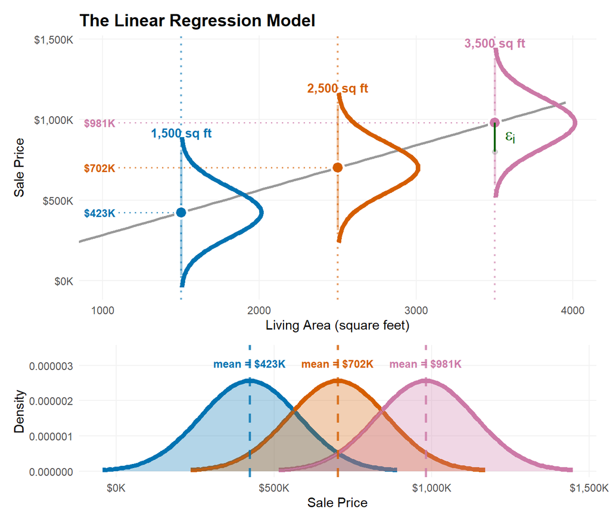

## Estimates vs True Values

- Our $\hat \beta_0, \hat \beta_1, ..., \hat \beta_p$ are just estimates of the true $\beta_0, \beta_1, ..., \beta_p$
- The residuals estimate the true prediction errors
- The RSE (standard deviation of residuals) is an estimate of the true $\sigma$ (error **standard deviation**)

## Accounting for uncertainty in estimates

- If we want to know how uncertain our estimates are, we need to quantify their variability.
- We can do this using the **sampling distribution** of our estimates (how much they change over repeated samples)
- More specifically, we can compute **confidence intervals**

## Confidence intervals

- A confidence interval gives a range of plausible values for a population parameter (e.g., a regression coefficient)
- These are possible values of the true coefficients that are consistent with our observed data at a given level of confidence (e.g., 95%)
- If our LINE assumptions hold, these are easy to get:

```r
confint(fit)
```

```
                   2.5 %      97.5 %
(Intercept) -36996.53678 45589.87298
area           259.29353   298.98532
```

## Returning to course evaluations

```
Call:
lm(formula = eval ~ beauty, data = profs)

Residuals:
    Min      1Q  Median      3Q     Max
-1.8002 -0.3630  0.0725  0.4021  1.1037

Coefficients:
            Estimate Std. Error t value             Pr(>|t|)
(Intercept)   3.9983     0.0253  157.73 < 0.0000000000000002 ***
beauty        0.1330     0.0322    4.13             0.000042 ***
---
Signif. codes:  0 '***' 0.001 '**' 0.01 '*' 0.05 '.' 0.1 ' ' 1

Residual standard error: 0.545 on 461 degrees of freedom
Multiple R-squared:  0.0357,    Adjusted R-squared:  0.0336
F-statistic: 17.1 on 1 and 461 DF,  p-value: 0.0000425
```

## Is there evidence for a linear relationship?

```r
confint(model_simple)
```

```
             2.5 % 97.5 %
(Intercept) 3.9485  4.048
beauty      0.0698  0.196
```

- The range of plausible values for the slope $\beta_1$ is (0.07, 0.20)
- No linear relationship would mean $\beta_1=0$
- All the plausible values are positive, so we have *statistically significant* evidence of a positive linear relationship between beauty and evaluations

## How strong is the linear relationship?

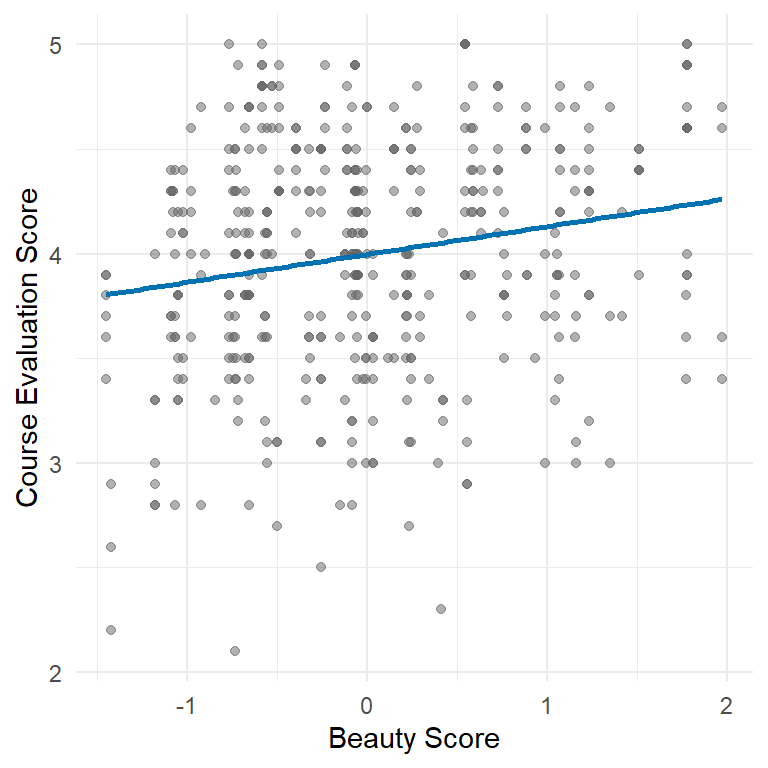

- $\text{Cor}(\text{beauty, eval}) = 0.19$
- $R^2$ = 0.036 – only 3.6% of the variance in eval is explained by beauty
- But we have strong statistical evidence that this (weak) linear relationship holds among the population of all instructors
- In other words, it isn’t just a fluke in this particular sample

## How strong is the linear relationship?

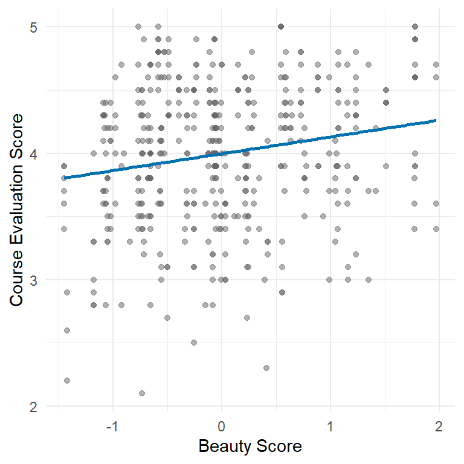

- Remember: $R^2$ doesn’t tell us directly how confident we are that a linear relationship exists
- In this case we have **strong evidence** of a **weak linear relationship**
- This is because many factors unrelated to beauty affect eval scores

## Accounting for uncertainty in predictions

If I’m selling a house I’d like to know:

- What’s the most likely sale price (best prediction)?
- What’s a range of likely sale prices (prediction interval)?

## Prediction intervals

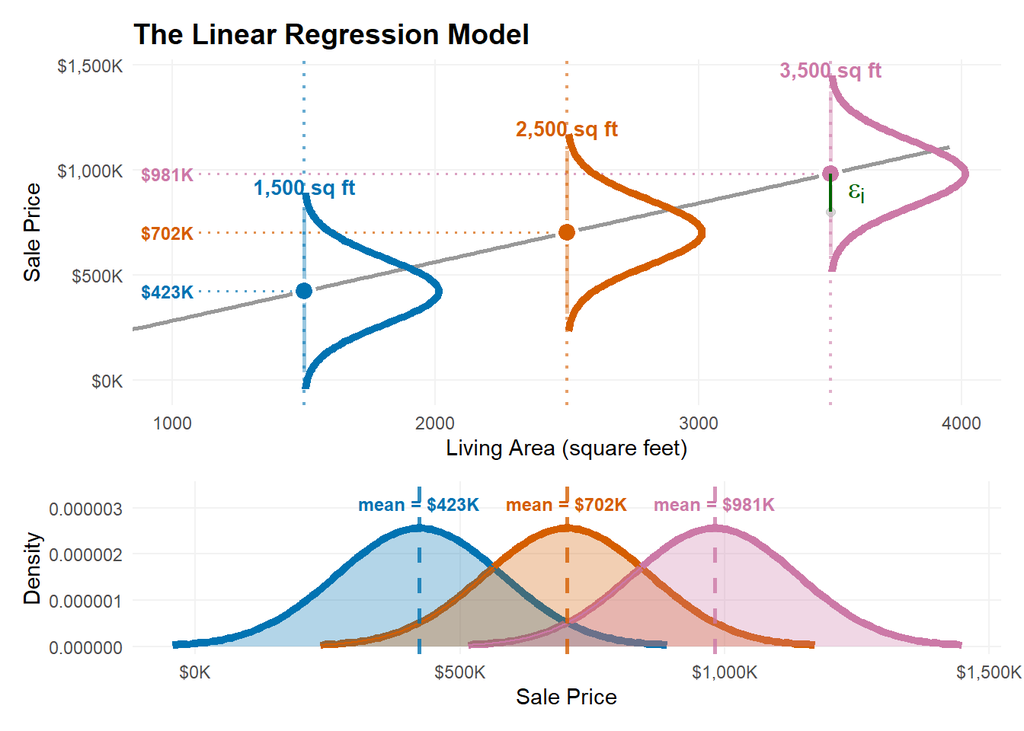

Our model says actual prices for houses of a given size will:

1. Have normal distributions
2. Centered at the predicted value (location on the line)
3. With standard deviation $\sigma$

95% of the time, actual prices fall within $\pm 2\sigma$ of the predicted price (if we knew the true line and $\sigma$)

## Prediction intervals

Under our LINE assumptions, we can get prediction intervals for new observations that account for both:

- Uncertainty in our estimated regression line
- The inherent variability in actual outcomes around that line

```r
new_house = data.frame(area = 2000)
predict(fit, newdata = new_house,
  interval = "prediction")
```

```
     fit    lwr    upr
1 562576 256519 868632
```

95% prediction interval: ($256,518, $868,632)

## Prediction intervals

```r
new_house = data.frame(area = 2000)
predict(fit, newdata = new_house,
  interval = "prediction")
```

```
     fit    lwr    upr
1 562576 256519 868632
```

- There’s a 95% chance that a new house will sell for a price in this range
- 95% of all future houses with 2000 sq ft will sell for between $256,518 and $868,632